# Jeff

https://github.com/jrkkv5/FIN6572Fall2020/blob/master/National%20Debt/importNationalDebt.Rmd

11/8/2020

# Introduction

The focus of this report is to examine unemployment within the United States. With unemployment as the dependent variable we examine its relationship with the house price index (HPI), real median household income (RMHI), poverty rate, population, and change in the S&P 500 index. The unemployment rates encompassed within our dataset are measured at the state level. In the ensuing report we provide a brief overview of all of the observations in the dataset and move on to examine two states, Illinois and West Virginia, at a more detailed level. This report seeks to prove that house price index (HPI), real median household income (RMHI), poverty rate, population, and change in the S&P 500 index have no direct effect on the unemployment rate at the state level.

```r
merged_final <- read_csv("csv files/mergedFinal.csv")
#Reads final file into merged dataframe

names(merged_final)[4] <- "unemployment"

merged_final$log_pop = as.numeric(log(merged_final$population))

merged_final$log_RMHI = as.numeric(log(merged_final$RMHI))
```

In the above code section the data is imported into R Studio and stored in the dataframe named merged_final.

As a final step before analyzing the data, two new variables are created to provide the logarithmic values of population and RMHI. By taking the logarithmic values, these variables become more comparable to the existing variables we have within our dataset. Below you can see the table output once all of our data has been merged.

```r
kable(merged_final[1:6,], caption = "Table Including All Variables")
```

Table Including All Variables

| year | period | periodName | unemployment | state | quarter | annual | HPI | MHI | RMHI | poverty | population | sp500 | log_pop | log_RMHI |
| --- | --- | --- | --- | --- | --- | --- | --- | --- | --- | --- | --- | --- | --- | --- |
| 1984 | M12 | December | 9.3 | AK | 4 | 1 | 153.82 | 32356 | 74689 | 9.6 | 513702 | 1.40 | 13.14940 | 11.22109 |
| 1985 | M12 | December | 10.1 | AK | 4 | 1 | 143.07 | 34782 | 77625 | 8.7 | 532495 | 26.33 | 13.18533 | 11.25964 |
| 1986 | M12 | December | 11.0 | AK | 4 | 1 | 138.24 | 31356 | 68775 | 11.4 | 544268 | 14.62 | 13.20720 | 11.13860 |
| 1987 | M12 | December | 9.5 | AK | 4 | 1 | 106.02 | 33233 | 70468 | 12.0 | 539309 | 2.03 | 13.19804 | 11.16291 |
| 1988 | M12 | December | 8.0 | AK | 4 | 1 | 133.16 | 33103 | 67745 | 11.0 | 541983 | 12.40 | 13.20299 | 11.12351 |
| 1989 | M12 | December | 7.1 | AK | 4 | 1 | 102.92 | 36006 | 70599 | 10.5 | 547159 | 27.25 | 13.21249 | 11.16477 |

# Unemployment: National Level

## Descriptive Statistics: National

```r
#Descriptive Statistics
stat.desc(c(merged_final$unemployment,merged_final$poverty))
```

```
##      nbr.val     nbr.null       nbr.na          min          max        range
## 3.600000e+03 0.000000e+00 0.000000e+00 1.800000e+00 2.720000e+01 2.540000e+01
##          sum       median         mean      SE.mean CI.mean.0.95          var
## 3.292160e+04 8.500000e+00 9.144889e+00 7.903007e-02 1.549482e-01 2.248471e+01
##      std.dev     coef.var
## 4.741804e+00 5.185196e-01
```

## Multiple Linear Regression: National

### Model 1: National

This project uses the ordinary least squares method to estimate the relationship between the independent variable and the dependent variables. The following model was estimated using OLS:

```r
US_reg1 <- lm(unemployment ~ HPI + poverty + sp500 + log_pop + log_RMHI , data = merged_final)
summary(US_reg1)
```

```
##
## Call:
## lm(formula = unemployment ~ HPI + poverty + sp500 + log_pop +
##     log_RMHI, data = merged_final)
##
## Residuals:
##     Min      1Q  Median      3Q     Max
## -3.4723 -1.2499 -0.3406  0.9330  7.7282
##
## Coefficients:
##               Estimate Std. Error t value Pr(>|t|)
## (Intercept) -2.745e+01  5.229e+00  -5.249 1.71e-07 ***
## HPI         -6.959e-04  4.125e-04  -1.687  0.09173 .
## poverty      3.330e-01  1.952e-02  17.057  < 2e-16 ***
## sp500       -3.824e-03  2.604e-03  -1.469  0.14210
## log_pop      1.140e-01  4.290e-02   2.657  0.00795 **
## log_RMHI     2.476e+00  4.765e-01   5.197 2.26e-07 ***
## ---
## Signif. codes:  0 '***' 0.001 '**' 0.01 '*' 0.05 '.' 0.1 ' ' 1
##
## Residual standard error: 1.709 on 1794 degrees of freedom
## Multiple R-squared:  0.2511, Adjusted R-squared:  0.249
## F-statistic: 120.3 on 5 and 1794 DF,  p-value: < 2.2e-16
```

```r
anova(US_reg1)
```

```
## Analysis of Variance Table
##
## Response: unemployment
##             Df Sum Sq Mean Sq F value    Pr(>F)
## HPI          1   56.8   56.82  19.450 1.094e-05 ***
## poverty      1 1567.3 1567.30 536.518 < 2.2e-16 ***
## sp500        1    3.6    3.63   1.241    0.2654
## log_pop      1   50.8   50.84  17.405 3.165e-05 ***
## log_RMHI     1   78.9   78.89  27.006 2.259e-07 ***
## Residuals 1794 5240.7    2.92
## ---
## Signif. codes:  0 '***' 0.001 '**' 0.01 '*' 0.05 '.' 0.1 ' ' 1
```

```r
ols_coll_diag(US_reg1)
```

```
## Tolerance and Variance Inflation Factor
## ---------------------------------------
##   Variables Tolerance      VIF
## 1       HPI 0.6663864 1.500631
## 2   poverty 0.3124067 3.200956
## 3     sp500 0.9722612 1.028530
## 4   log_pop 0.8594747 1.163501
## 5  log_RMHI 0.2610110 3.831256
##
##
## Eigenvalue and Condition Index
## ------------------------------
##     Eigenvalue Condition Index    intercept         HPI      poverty
## 1 5.084306e+00        1.000000 2.260510e-06 0.003830323 0.0008573464
## 2 7.057245e-01        2.684097 8.309778e-07 0.007536975 0.0001713296
## 3 1.629915e-01        5.585130 5.822419e-06 0.492530632 0.0376522800
## 4 4.410114e-02       10.737198 1.625945e-04 0.254881390 0.2979309140
## 5 2.846922e-03       42.259862 3.318598e-03 0.010335689 0.0184470508
## 6 2.980417e-05      413.025926 9.965099e-01 0.230884991 0.6449410792
##          sp500      log_pop     log_RMHI
## 1 0.0096374541 1.473821e-04 2.269970e-06
## 2 0.9272088469 5.768935e-05 8.654638e-07
## 3 0.0540411332 3.334540e-04 3.680338e-06
## 4 0.0046490202 7.420650e-03 1.977518e-04
## 5 0.0003590656 9.471835e-01 2.962749e-03
## 6 0.0041044801 4.485731e-02 9.968327e-01
```

The first multiple regression for US is conducted with five independent variables, four of the coefficients on the predictor variables have the expected signs except the real median household income (log). The Logarithm of real median household income has a positive sign when it is expected have a negative sign. The wrong sign could be explained partly by it having the highest variance inflation factor (VIF) of 3.831, but it is not high enough to indicate multicollinearity.

According to the low VIF values, between 1.029 and 3.831, the variables are not correlated with each other. With VIF values being so low, the p-value becomes a reliable way to test significance of the independent variables on the dependent variable, unemployment. The p values of our sample indicate that three of the variables are statistically significant at the 5% level of significance. Using the p values we find that the house price index (HPI) and change in the S&P 500 index are insignificant.

The overall fit of the estimated model using all of our independent variables does not appear to be good because the coefficient of determination (R-squared) and the coefficient of multiple determination (Adjusted R-squared) of the model are low. The model has an R-squared value of 0.2511 and the Adjusted R-squared is 0.249 which indicates that the model explains 25.11% of the variation in the unemployment rate data around its mean.

A second regression will be executed to exclude the S&P 500 and HPI data improve the model.

### Model 2: National

```r
US_linearModelSignificant <- lm(unemployment ~ poverty + log_pop + log_RMHI , data = merged_final)
summary(US_linearModelSignificant)
```

```
##
## Call:
## lm(formula = unemployment ~ poverty + log_pop + log_RMHI, data = merged_final)
##
## Residuals:
##     Min      1Q  Median      3Q     Max
## -3.3504 -1.2408 -0.3391  0.9613  7.6779
##
## Coefficients:
##              Estimate Std. Error t value Pr(>|t|)
## (Intercept) -23.30218    4.59719  -5.069 4.42e-07 ***
## poverty       0.32451    0.01900  17.081  < 2e-16 ***
## log_pop       0.11148    0.04286   2.601  0.00936 **
## log_RMHI      2.09117    0.41764   5.007 6.07e-07 ***
## ---
## Signif. codes:  0 '***' 0.001 '**' 0.01 '*' 0.05 '.' 0.1 ' ' 1
##
## Residual standard error: 1.71 on 1796 degrees of freedom
## Multiple R-squared:  0.2493, Adjusted R-squared:  0.2481
## F-statistic: 198.8 on 3 and 1796 DF,  p-value: < 2.2e-16
```

```r
anova(US_linearModelSignificant)
```

```
## Analysis of Variance Table
##
## Response: unemployment
##             Df Sum Sq Mean Sq F value    Pr(>F)
## poverty      1 1612.0 1612.05 551.110 < 2.2e-16 ***
## log_pop      1   59.4   59.36  20.292 7.076e-06 ***
## log_RMHI     1   73.3   73.33  25.071 6.069e-07 ***
## Residuals 1796 5253.5    2.93
## ---
## Signif. codes:  0 '***' 0.001 '**' 0.01 '*' 0.05 '.' 0.1 ' ' 1
```

```r
ols_coll_diag(US_linearModelSignificant)
```

```
## Tolerance and Variance Inflation Factor
## ---------------------------------------
##   Variables Tolerance      VIF
## 1   poverty 0.3303144 3.027418
## 2   log_pop 0.8623005 1.159688
## 3  log_RMHI 0.3402174 2.939297
##
##
## Eigenvalue and Condition Index
## ------------------------------
##     Eigenvalue Condition Index    intercept     poverty     log_pop
## 1 3.9384950164        1.000000 4.932158e-06 0.001552346 0.000248892
## 2 0.0585781558        8.199688 1.010865e-04 0.324619112 0.004032120
## 3 0.0028880793       36.928409 4.492658e-03 0.013337209 0.922054556
## 4 0.0000387485      318.814245 9.954013e-01 0.660491333 0.073664432
##       log_RMHI
## 1 4.975997e-06
## 2 1.424391e-04
## 3 3.869113e-03
## 4 9.959835e-01
```

The result of our second regression shows that log_RHMI variable still has the incorrect sign. With the two variables excluded, the VIF value range decreases, ranging between 1.160 and 3.027, indicating no multicollinearity among the independent variables. The p-values were still statistically significant at the 5% level of significance. Log_pop is the least significant variable, but it has the lowest VIF value. The overall fit of the estimated model does not appear to be good because the coefficient of determination for the regression is low. The models R-squared is 0.2493 and the Adjusted R-squared is 0.2481 which shows a slight decrease when compared to the original regression.

A possible explanation for the low coefficients of determination is because the data we collected is measured at the state level. As the economy of each state varies widely, we expect the R-squared and Adjusted R-squared values to increase when measured at the state level. To accurately model the regression at the national level it would be helpful to pull data at the national level.

## Histograms: National

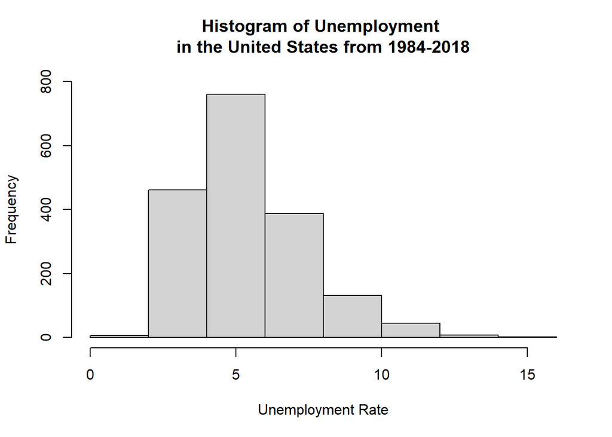

```r
hist(merged_final$unemployment,
     main="Histogram of Unemployment \nin the United States from 1984-2018",
     ylim = c(0,800),
     xlab="Unemployment Rate",
     breaks = 5)
```

Histograms graphically summarize the frequency distribution of a data set. In the United States, from 1984 to 2018, the annual unemployment rate ranges from 1.8%-14.4%. The histogram displays a slight positive skew. Overall the most frequent unemployment rate in the United States over this time period hovers around 5%.

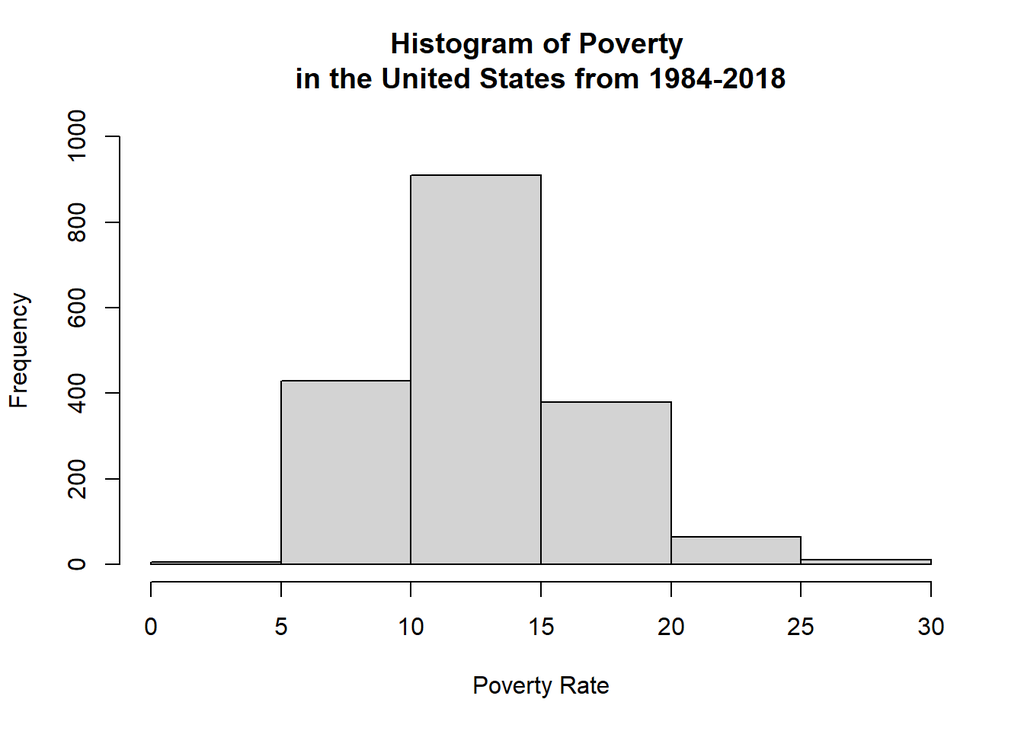

```r
hist(merged_final$poverty,
     main="Histogram of Poverty \nin the United States from 1984-2018",
     ylim = c(0,1000),
     xlab="Poverty Rate",
     breaks = 5)
```

The histogram of the poverty rate in the United States graphically shows much more of a normal distribution. This is demonstrated by the bell curve that is formed in the graph above. In the United States, from 1984 to 2018, the annual poverty rate ranges from 2.9%-27.2%. Based on the normal distribution it can be assumed that the observations for poverty rate are evenly distributed around the mean 12.85%.

### Further Analysis

After all of the data is merged we binned the states into groups based on the mean population of the years in our dataframe (1984-2018). Below are the bins that were created:

Population < 2,000,000 WV, NM, NE, ID, ME, HI, NH, RI, MT, DE, SD, ND, AK, VT, WY

2,000,000 < Population < 5,000,000 MN, AL, LA, CO, SC, KY, OK, OR, CT, IA, MS, KS, AR, UT, NV

5,000,000 < Population < 10,000,000 MI, NJ, GA, NC, VA, MA, IN, WA, TN, MO, WI, MD, AZ

Population > 10,000,000 CA, TX, NY, FL, PA, IL, OH

Each member of our group performed some basic analysis on the states within one of the bins. After performing our initial analysis we chose to focus on 2 states: Illinois and West Virginia. The remaineder of the analysis in this report will center around the state of West Virginia and Illinois.

Below are some of the highlights along with commentary for the states we have chosen to focus on.

# Unemployment: Illinois

## Descriptive Statistics: Illinois

```r
IL_data <- merged_final[ merged_final$state == "IL", ]
```

```r
#Descriptive statistics
stat.desc(IL_data)
```

```
##                      year period periodName unemployment state quarter annual
## nbr.val      3.600000e+01     NA         NA   36.0000000    NA      36     36
## nbr.null     0.000000e+00     NA         NA    0.0000000    NA       0      0
## nbr.na       0.000000e+00     NA         NA    0.0000000    NA       0      0
## min          1.984000e+03     NA         NA    4.1000000    NA       4      1
## max          2.018000e+03     NA         NA   11.0000000    NA       4      1
## range        3.400000e+01     NA         NA    6.9000000    NA       0      0
## sum          7.204500e+04     NA         NA  231.7000000    NA     144     36
## median       2.001500e+03     NA         NA    6.1000000    NA       4      1
## mean         2.001250e+03     NA         NA    6.4361111    NA       4      1
## SE.mean      1.701715e+00     NA         NA    0.3023493    NA       0      0
## CI.mean.0.95 3.454665e+00     NA         NA    0.6138018    NA       0      0
## var          1.042500e+02     NA         NA    3.2909444    NA       0      0
## std.dev      1.021029e+01     NA         NA    1.8140960    NA       0      0
## coef.var     5.101956e-03     NA         NA    0.2818621    NA       0      0
##                      HPI          MHI         RMHI     poverty   population
## nbr.val        36.000000 3.600000e+01 3.600000e+01  36.0000000 3.600000e+01
## nbr.null        0.000000 0.000000e+00 0.000000e+00   0.0000000 0.000000e+00
## nbr.na          0.000000 0.000000e+00 0.000000e+00   0.0000000 0.000000e+00
## min           112.800000 2.375200e+04 5.482800e+04   9.9000000 1.138726e+07
## max           371.210000 7.014500e+04 7.014500e+04  15.6000000 1.289827e+07
## range         258.410000 4.639300e+04 1.531700e+04   5.7000000 1.511012e+06
## sum          9218.510000 1.587843e+06 2.204043e+06 451.4000000 4.422845e+08
## median        276.190000 4.607050e+04 6.109050e+04  12.6000000 1.250700e+07
## mean          256.069722 4.410675e+04 6.122342e+04  12.5388889 1.228568e+07
## SE.mean        13.176322 1.969590e+03 6.769020e+02   0.2635917 9.375302e+04
## CI.mean.0.95   26.749355 3.998480e+03 1.374184e+03   0.5351197 1.903288e+05
## var          6250.156368 1.396542e+08 1.649507e+07   2.5013016 3.164266e+11
## std.dev        79.057930 1.181754e+04 4.061412e+03   1.5815504 5.625181e+05
## coef.var        0.308736 2.679304e-01 6.633756e-02   0.1261316 4.578648e-02
##                   sp500      log_pop     log_RMHI
## nbr.val       36.000000 3.600000e+01 3.600000e+01
## nbr.null       1.000000 0.000000e+00 0.000000e+00
## nbr.na         0.000000 0.000000e+00 0.000000e+00
## min          -38.490000 1.624801e+01 1.091196e+01
## max           34.110000 1.637260e+01 1.115832e+01
## range         72.600000 1.245982e-01 2.463635e-01
## sum          341.220000 5.876247e+02 3.967264e+02
## median        11.895000 1.634180e+01 1.102010e+01
## mean           9.478333 1.632291e+01 1.102018e+01
## SE.mean        2.652485 7.733796e-03 1.093321e-02
## CI.mean.0.95   5.384831 1.570044e-02 2.219560e-02
## var          253.284340 2.153217e-03 4.303264e-03
## std.dev       15.914909 4.640277e-02 6.559927e-02
## coef.var       1.679083 2.842801e-03 5.952651e-03
```

```r
#pairwise correlations
sapply(IL_data, class)
```

```
##         year       period   periodName unemployment        state      quarter
##    "numeric"  "character"  "character"    "numeric"  "character"    "numeric"
##       annual          HPI          MHI         RMHI      poverty   population
##    "numeric"    "numeric"    "numeric"    "numeric"    "numeric"    "numeric"
##        sp500      log_pop     log_RMHI
##    "numeric"    "numeric"    "numeric"
```

```r
sapply(IL_data, is.factor)
```

```
##         year       period   periodName unemployment        state      quarter
##        FALSE        FALSE        FALSE        FALSE        FALSE        FALSE
##       annual          HPI          MHI         RMHI      poverty   population
##        FALSE        FALSE        FALSE        FALSE        FALSE        FALSE
##        sp500      log_pop     log_RMHI
##        FALSE        FALSE        FALSE
```

```r
cor(IL_data[sapply(IL_data, function(x) !is.character(x))])
```

```
##                      year unemployment quarter annual         HPI        MHI
## year          1.000000000  0.006748569      NA     NA  0.91598238  0.9754798
## unemployment  0.006748569  1.000000000      NA     NA -0.08115831 -0.1343498
## quarter                NA           NA       1     NA          NA         NA
## annual                 NA           NA      NA      1          NA         NA
## HPI           0.915982382 -0.081158315      NA     NA  1.00000000  0.9020434
## MHI           0.975479844 -0.134349785      NA     NA  0.90204345  1.0000000
## RMHI          0.369670810 -0.659000548      NA     NA  0.39861034  0.5518278
## poverty      -0.360502692  0.697578917      NA     NA -0.47108192 -0.5052706
## population    0.955653199  0.020119683      NA     NA  0.93700387  0.9194634
## sp500        -0.138529275  0.031097916      NA     NA -0.21926746 -0.1520508
## log_pop       0.953215398  0.011231165      NA     NA  0.93704886  0.9183431
## log_RMHI      0.373224106 -0.660277555      NA     NA  0.40824269  0.5536662
##                     RMHI     poverty  population       sp500     log_pop
## year          0.36967081 -0.36050269  0.95565320 -0.13852928  0.95321540
## unemployment -0.65900055  0.69757892  0.02011968  0.03109792  0.01123117
## quarter               NA          NA          NA          NA          NA
## annual                NA          NA          NA          NA          NA
## HPI           0.39861034 -0.47108192  0.93700387 -0.21926746  0.93704886
## MHI           0.55182782 -0.50527064  0.91946339 -0.15205085  0.91834308
## RMHI          1.00000000 -0.86935532  0.36060017 -0.04610779  0.36698125
## poverty      -0.86935532  1.00000000 -0.40348032  0.08946888 -0.41069905
## population    0.36060017 -0.40348032  1.00000000 -0.15320230  0.99988750
## sp500        -0.04610779  0.08946888 -0.15320230  1.00000000 -0.15281783
## log_pop       0.36698125 -0.41069905  0.99988750 -0.15281783  1.00000000
## log_RMHI      0.99934815 -0.87399522  0.36621331 -0.04538721  0.37261639
##                 log_RMHI
## year          0.37322411
## unemployment -0.66027755
## quarter               NA
## annual                NA
## HPI           0.40824269
## MHI           0.55366622
## RMHI          0.99934815
## poverty      -0.87399522
## population    0.36621331
## sp500        -0.04538721
## log_pop       0.37261639
## log_RMHI      1.00000000
```

## Histograms: Illinois

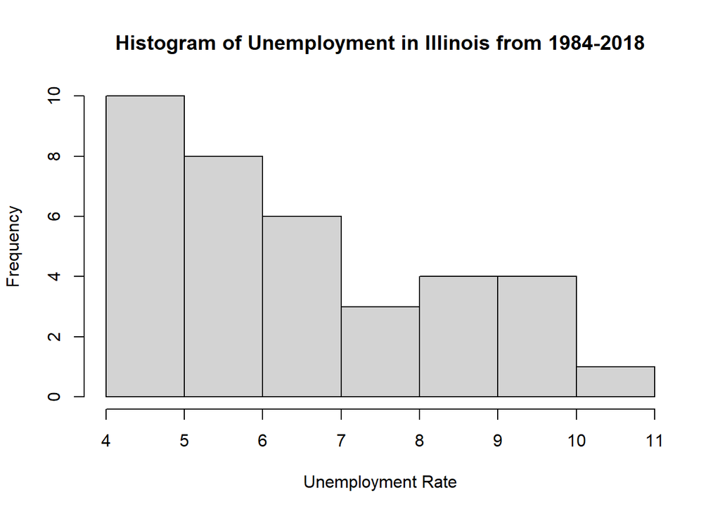

```r
hist(IL_data$unemployment,
     main="Histogram of Unemployment in Illinois from 1984-2018",
     xlim=c(4,11),
     xlab="Unemployment Rate",
     breaks = 5)
```

In Illinois, from 1984 to 2018, the annual unemployment rates ranged from 4.1-11.0%. The histogram displays a positively skewed distribution. An unemployment rate that fell within the first two intervals, 4.0-4.9% & 5.0-5.9%, occurred 18 out of the 36 years examined.

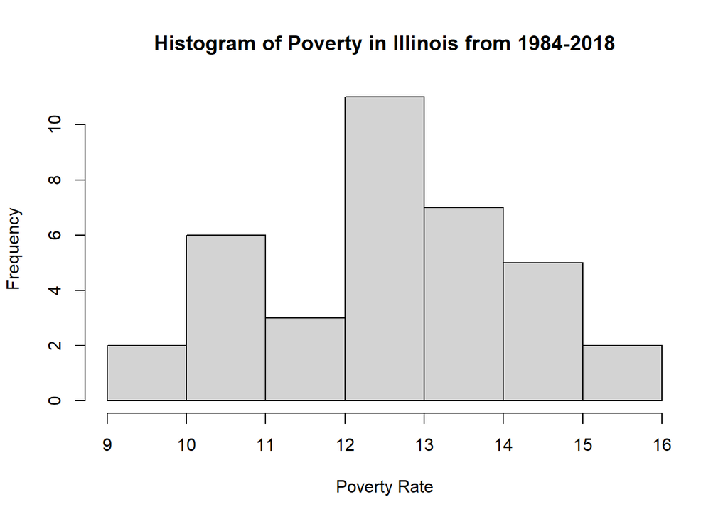

```r
hist(IL_data$poverty,
     main="Histogram of Poverty in Illinois from 1984-2018",
     xlim=c(9,16),
     xlab="Poverty Rate",
     breaks = 5)
```

In Illinois, from 1984 to 2018, the poverty levels range from 9.9-15.6%. The histogram pictured above displays a relatively normal distribution. Illinois registered an poverty rate between 12.0-12.9% most frequently during this time period. In 14 of the 36 years examined, the poverty rate in Illinois was between 13-15.9%.

## Scatter Plots: Illinois

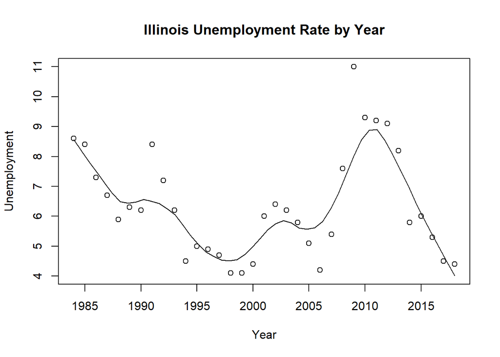

```r
scatter.smooth(IL_data$year, IL_data$unemployment, main="Illinois Unemployment Rate by Year", xlab = "Year", ylab = "Unemployment", span = 2/8)
```

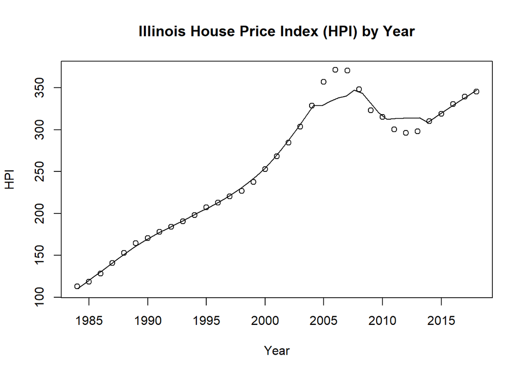

```r
scatter.smooth(IL_data$year, IL_data$HPI, main="Illinois House Price Index (HPI) by Year", xlab = "Year", ylab = "HPI", span = 2/8)
```

This plot represents the relationship between Illinois’ house price index (HPI) and the year. From 1984 to 2008 the relationship appears to be linear until the HPI dipped in 2008-2013. Since then, the HPI has continued its increase in a linear fashion. This pattern is observed consistently when examining many other states and, through inference, can mainly be attributed to the fallout the Great Recession caused in the housing market.

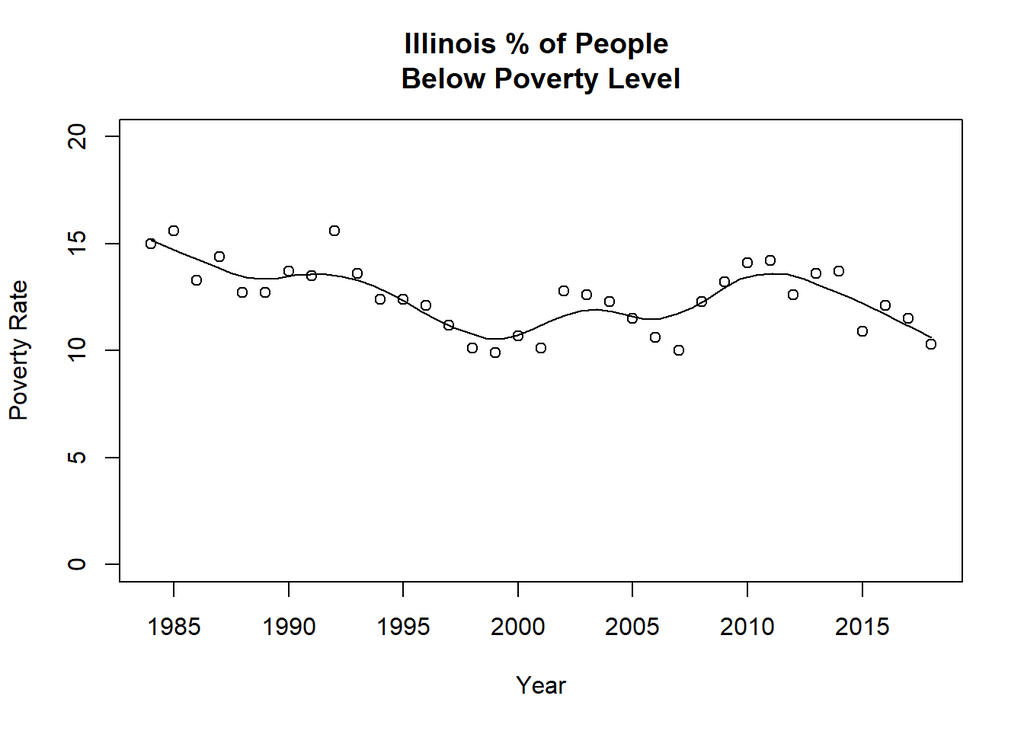

```r
scatter.smooth(x=IL_data$year, y=IL_data$poverty, main="Illinois % of People \nBelow Poverty Level", xlab = "Year", ylab = "Poverty Rate", ylim = c(0,20), span = 2/8)
```

The percentage of individuals living below the poverty rate in Illinois does not display a clear pattern. Although, a slight cyclical pattern can be observed in the data. Overall, there has been slight decrease of roughly 4% from 1984 to 2018. Poverty levels for the state of Illinois peaked in 1992.

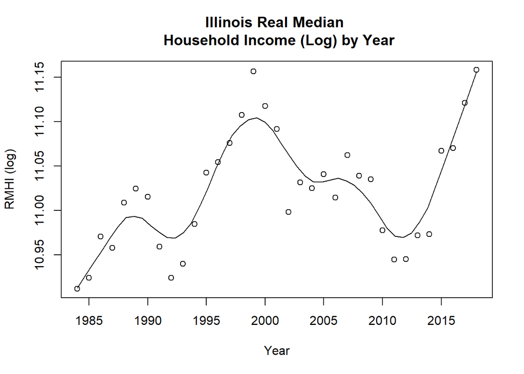

```r
#IL_data$log_RMHI <- as.integer(IL_data$log_RMHI)
scatter.smooth(x=IL_data$year, y=IL_data$log_RMHI, main="Illinois Real Median \n Household Income (Log) by Year", xlab = "Year", ylab = "RMHI (log)", span = 2/8 )
```

The median household income in Illinois increases dramatically from 1984-2018. The lowest and highest values recorded fall at the beginning and the end of the time period, respectively. There are several peaks and valleys that can be observed in the scatter plot. Again, as this is a financial measure, the cyclical nature of this graph follows the ebb and flow of the United States economy.

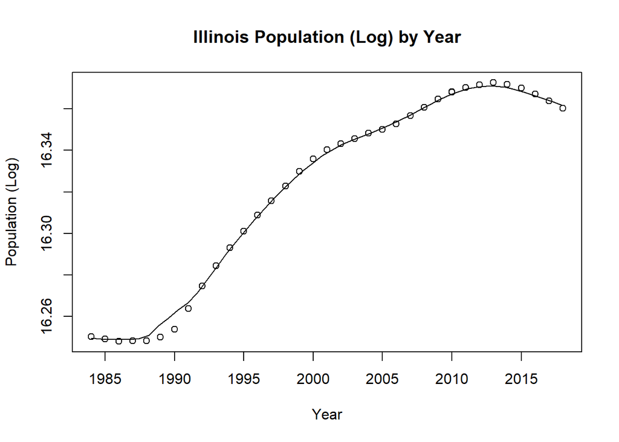

```r
#IL_data$log_pop <- as.integer(IL_data$log_pop)
scatter.smooth(x=IL_data$year, y=IL_data$log_pop, main="Illinois Population (Log) by Year", xlab = "Year", ylab = "Population (Log)", span = 2/8)
```

The logarithmic population of Illinois decreased slightly from 1984-1988 before increasing in a relatively linear fashion from 1988 to its peak in 2013. From 2013-2018 there is a gradual decline in population within the state.

## Correlations: Illinois

A correlation function is used to illustrate the relationship between our independent variable and our dependent variable. The closer the correlation is to 1 or -1 the stronger the correlation between the two variables. For a correlation of 1, it signifies that there is a perfect positive correlation. For a -1 correlation there is a perfect inverse relationship between the two variables.

```r
cor(IL_data$HPI, IL_data$unemployment)
```

```
## [1] -0.08115831
```

The correlation between HPI (House Price Index) and our dependent variable, unemployment, in Illinois is -0.08115831. The correlation shows that there is a weak negative relationship between the housing price and unemployment in the State of Illinois.

```r
cor(IL_data$poverty, IL_data$unemployment)
```

```
## [1] 0.6975789
```

The correlation between the poverty rate, the percentage of the population under the poverty line, and unemployment in Illinois is 0.6975789. This correlation shows a much stronger positive relationship between the two variables. As unemployment increases there is a much stronger possibility that the percentage of the population under the poverty line increases as well.

```r
cor(IL_data$sp500, IL_data$unemployment)
```

```
## [1] 0.03109792
```

The correlation between the change in the S&P 500 and unemployment in Illinois is 0.03109792. The correlation between the S&P 500 and unemployment shows a weak positive correlation. With the correlation being extremely close to 0 it signifies that there is not much of an explanatory relationship between the two variables.

```r
cor(IL_data$log_pop, IL_data$unemployment)
```

```
## [1] 0.01123117
```

The correlation between the log of the population and unemployment in Illinois is 0.01123117. The correlation between the log of the population and unemployment is extremely close to 0, which signifies there is almost no correlation between the two variables.

```r
cor(IL_data$log_RMHI, IL_data$unemployment)
```

```
## [1] -0.6602776
```

The correlation between the log of real median household income and unemployment in Illinois is -0.6602776. The relationship between the log of median household income and unemployment represents a strong negative correlation. This suggests that the two variables move in inverse directions of each other. In this case, with a correlation of -0.66, there is enough evidence to suggest that in most cases the two variables move in inverse directions of each other due to the proximity of -0.66 to -1, which is a perfect negative relationship.

## Boxplots: Illinois

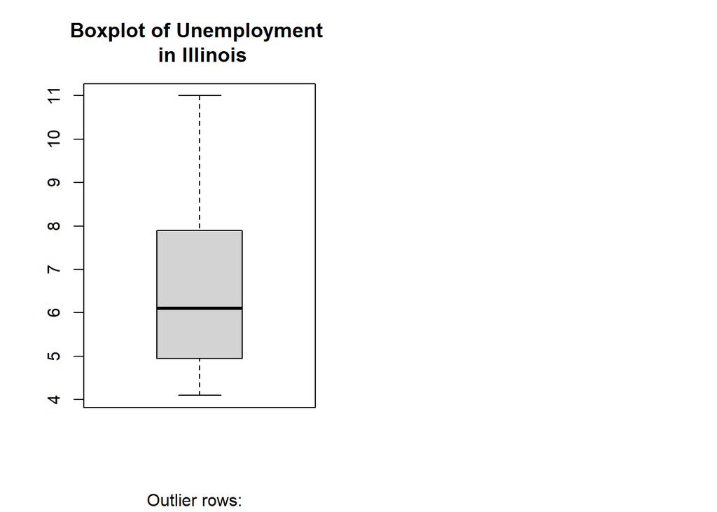

```r
par(mfrow=c(1, 2))  # divide graph area in 2 columns
boxplot(IL_data$unemployment, main="Boxplot of Unemployment \n in Illinois", sub=paste("Outlier rows: ", boxplot.stats(IL_data$unemployment)$out))  # box plot for 'Unemployment'
```

The annual unemployment rate in Illinois ranges from 4%-11% during the time period of 1984-2018. The boxplot for unemployment rate displays a positively skewed distribution. This shows us that the mean is greater than the median. There were no outliers in the Unemployment data collected from 1984-2018 based upon the boxplot results.

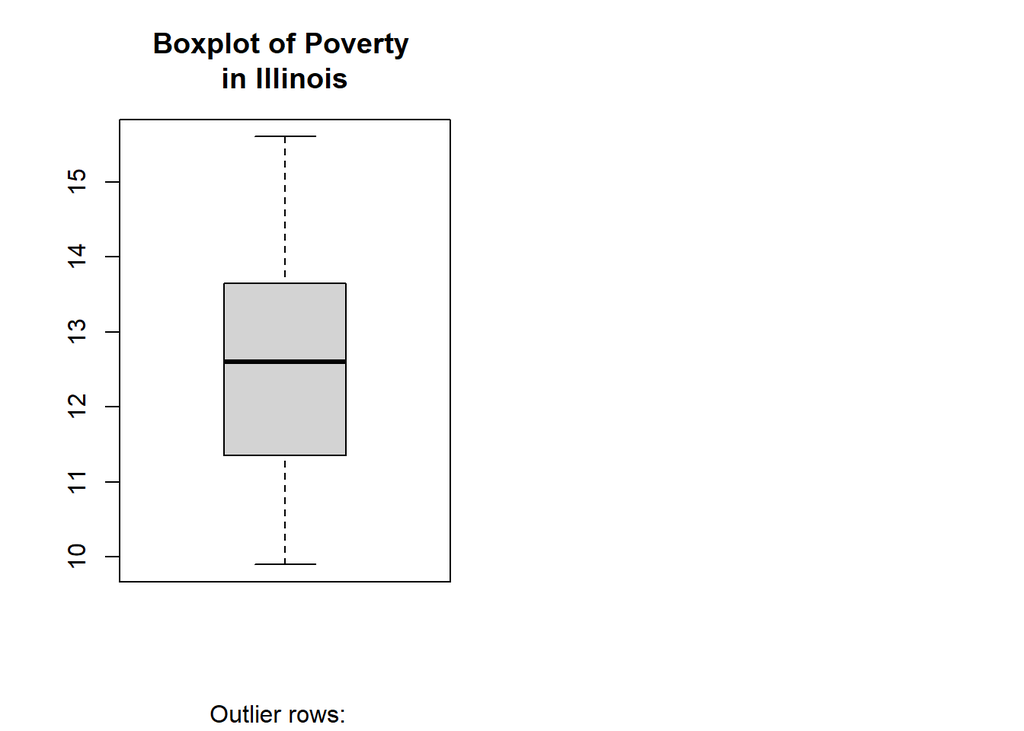

```r
par(mfrow=c(1, 2))  # divide graph area in 2 columns
boxplot(IL_data$poverty, main="Boxplot of Poverty \nin Illinois", sub=paste("Outlier rows: ", boxplot.stats(IL_data$poverty)$out))  # box plot for 'Poverty'
#create box plot for poverty level and unemployment level
```

## Multiple Linear Regression: Illinois

### Model 1: Illinois

This project uses the ordinary least squares method to estimate the relationship between the independent variable and the dependent variable. The following model was estimated using OLS:

```r
IL_reg2 <- lm(unemployment ~ HPI + poverty + sp500 + log_pop + log_RMHI , data = IL_data)
summary(IL_reg2)
```

```
##
## Call:
## lm(formula = unemployment ~ HPI + poverty + sp500 + log_pop +
##     log_RMHI, data = IL_data)
##
## Residuals:
##     Min      1Q  Median      3Q     Max
## -2.5575 -0.7142 -0.0868  0.7908  3.6217
##
## Coefficients:
##               Estimate Std. Error t value Pr(>|t|)
## (Intercept) -2.701e+02  2.170e+02  -1.245   0.2228
## HPI         -4.554e-03  7.999e-03  -0.569   0.5733
## poverty      6.973e-01  2.810e-01   2.481   0.0189 *
## sp500        5.088e-04  1.349e-02   0.038   0.9702
## log_pop      2.113e+01  1.303e+01   1.621   0.1154
## log_RMHI    -6.889e+00  6.524e+00  -1.056   0.2994
## ---
## Signif. codes:  0 '***' 0.001 '**' 0.01 '*' 0.05 '.' 0.1 ' ' 1
##
## Residual standard error: 1.222 on 30 degrees of freedom
## Multiple R-squared:  0.6109, Adjusted R-squared:  0.546
## F-statistic: 9.418 on 5 and 30 DF,  p-value: 1.773e-05
```

```r
anova(IL_reg2)
```

```
## Analysis of Variance Table
##
## Response: unemployment
##           Df Sum Sq Mean Sq F value    Pr(>F)
## HPI        1  0.759   0.759  0.5078    0.4816
## poverty    1 64.356  64.356 43.0732 2.924e-07 ***
## sp500      1  0.076   0.076  0.0507    0.8234
## log_pop    1  3.503   3.503  2.3446    0.1362
## log_RMHI   1  1.666   1.666  1.1149    0.2994
## Residuals 30 44.823   1.494
## ---
## Signif. codes:  0 '***' 0.001 '**' 0.01 '*' 0.05 '.' 0.1 ' ' 1
```

```r
ols_coll_diag(IL_reg2)
```

```
## Tolerance and Variance Inflation Factor
## ---------------------------------------
##   Variables Tolerance      VIF
## 1       HPI 0.1067566 9.367099
## 2   poverty 0.2160991 4.627507
## 3     sp500 0.9256652 1.080304
## 4   log_pop 0.1167693 8.563894
## 5  log_RMHI 0.2330766 4.290436
##
##
## Eigenvalue and Condition Index
## ------------------------------
##     Eigenvalue Condition Index    intercept          HPI      poverty
## 1 5.212873e+00        1.000000 3.213087e-08 0.0003060912 1.182875e-04
## 2 7.048766e-01        2.719456 1.255808e-08 0.0004722352 3.265087e-05
## 3 7.437527e-02        8.371906 2.975512e-07 0.0901005088 8.114782e-03
## 4 7.869031e-03       25.738188 1.135669e-05 0.0538621804 2.598235e-01
## 5 5.223247e-06      999.006459 2.739175e-02 0.0291556497 7.311859e-01
## 6 4.635005e-07     3353.617259 9.725966e-01 0.8261033348 7.249027e-04
##         sp500      log_pop     log_RMHI
## 1 0.008655549 3.343795e-08 2.925772e-07
## 2 0.890894671 1.324855e-08 1.153413e-07
## 3 0.068542989 2.746554e-07 2.334526e-06
## 4 0.004916631 1.138634e-05 1.356666e-04
## 5 0.001329368 3.367494e-02 9.912410e-01
## 6 0.025660791 9.663134e-01 8.620576e-03
```

The first multiple regression for Illinois is conducted with all five independent variables. Four of the coefficients of the predictor variables have the expected signs with the exception of the sp500 variable. The change in the S&P 500 index has a positive sign when it is expected to have a negative one. The incorrect direction of the sign could be explained partly by the high VIF values. The high VIF values indicate that some variables show high multicollinearity within the model.

The VIF values range from 1.080 and 9.367 signifying the variables are correlated with each other. The high VIF values suggest the p-value is unreliable to test significance of the independent variables.

The overall fit of the estimated regression model appears to be good because the R-squared value is reaching mid-level. The models coefficient of determination is 0.6109 and the Adjusted R-sq is 0.546, which indicates that the model explains approximately 54.6-61.09% of the variation in the unemployment rate data around its mean.

A second regression is made excluding the HPI, which has the highest VIF value, in order to improve the model.

### Model 2: Illinois

```r
IL_linearModelSignificant <- lm(unemployment ~ poverty + sp500 + log_pop + log_RMHI, data = IL_data)
summary(IL_linearModelSignificant)
```

```
##
## Call:
## lm(formula = unemployment ~ poverty + sp500 + log_pop + log_RMHI,
##     data = IL_data)
##
## Residuals:
##     Min      1Q  Median      3Q     Max
## -2.4952 -0.8111 -0.0466  0.7237  3.5540
##
## Coefficients:
##               Estimate Std. Error t value Pr(>|t|)
## (Intercept) -1.629e+02  1.069e+02  -1.525  0.13746
## poverty      7.314e-01  2.716e-01   2.693  0.01131 *
## sp500        2.163e-03  1.303e-02   0.166  0.86924
## log_pop      1.426e+01  4.874e+00   2.925  0.00638 **
## log_RMHI    -6.582e+00  6.430e+00  -1.024  0.31394
## ---
## Signif. codes:  0 '***' 0.001 '**' 0.01 '*' 0.05 '.' 0.1 ' ' 1
##
## Residual standard error: 1.209 on 31 degrees of freedom
## Multiple R-squared:  0.6066, Adjusted R-squared:  0.5559
## F-statistic: 11.95 on 4 and 31 DF,  p-value: 5.449e-06
```

```r
anova (IL_linearModelSignificant)
```

```
## Analysis of Variance Table
##
## Response: unemployment
##           Df Sum Sq Mean Sq F value    Pr(>F)
## poverty    1 56.050  56.050 38.3498 7.099e-07 ***
## sp500      1  0.114   0.114  0.0779   0.78202
## log_pop    1 12.180  12.180  8.3337   0.00703 **
## log_RMHI   1  1.531   1.531  1.0478   0.31394
## Residuals 31 45.308   1.462
## ---
## Signif. codes:  0 '***' 0.001 '**' 0.01 '*' 0.05 '.' 0.1 ' ' 1
```

```r
ols_coll_diag(IL_linearModelSignificant)
```

```
## Tolerance and Variance Inflation Factor
## ---------------------------------------
##   Variables Tolerance      VIF
## 1   poverty 0.2263803 4.417345
## 2     sp500 0.9706798 1.030206
## 3   log_pop 0.8164408 1.224829
## 4  log_RMHI 0.2346725 4.261257
##
##
## Eigenvalue and Condition Index
## ------------------------------
##     Eigenvalue Condition Index    intercept      poverty       sp500
## 1 4.312444e+00        1.000000 1.880054e-07 0.0001812932 0.014707177
## 2 6.757467e-01        2.526212 1.215539e-07 0.0001007135 0.958529764
## 3 1.179962e-02       19.117355 2.149252e-05 0.2199264942 0.005274288
## 4 6.991162e-06      785.393072 3.571135e-03 0.2965228112 0.018359682
## 5 2.391996e-06     1342.707940 9.964071e-01 0.4832686879 0.003129089
##        log_pop     log_RMHI
## 1 3.391958e-07 4.273829e-07
## 2 2.207621e-07 2.771424e-07
## 3 4.189301e-05 6.777289e-05
## 4 4.167257e-01 6.223448e-01
## 5 5.832319e-01 3.775867e-01
```

The second regression result show that sp500 variable still has the incorrect sign, however with the HPI variable excluded, the VIF values significantly decrease ranging between 1.030 and 4.417. This indicates less multicollinearity exists among the independent variables in the second model for Illinois. The p-values are statistically significant at the 5% level of significance for poverty and log_pop variables. Sp500 and Log_RMHI are not statistically significant according to their p-values.

The overall fit of the estimated model appears to be good because the R-squared value of the regression is again in the mid-level range. The model has a coefficient of determination of 0.6066 which is decreased slightly compared to the first regression, but the adjusted R-squared, 0.5559, increased compared to the first regression model. Overall the explanatory value of the second model is increased compared to the first regression analysis for the state of Illinois. There is a marked increase in the R-squared and Adjusted R-squared values compared to the initial model that included all of the states. This is indicative that the dataset has more explanatory power at the state level.

# Unemployment: West Virginia

## Descriptive Statistics: West Virginia

```r
WV_data <- merged_final[ merged_final$state == "WV", ]
```

```r
#Descriptive statistics
stat.desc(WV_data)
```

```
##                      year period periodName unemployment state quarter annual
## nbr.val      3.600000e+01     NA         NA   36.0000000    NA      36     36
## nbr.null     0.000000e+00     NA         NA    0.0000000    NA       0      0
## nbr.na       0.000000e+00     NA         NA    0.0000000    NA       0      0
## min          1.984000e+03     NA         NA    4.2000000    NA       4      1
## max          2.018000e+03     NA         NA   14.4000000    NA       4      1
## range        3.400000e+01     NA         NA   10.2000000    NA       0      0
## sum          7.204500e+04     NA         NA  260.6000000    NA     144     36
## median       2.001500e+03     NA         NA    6.8000000    NA       4      1
## mean         2.001250e+03     NA         NA    7.2388889    NA       4      1
## SE.mean      1.701715e+00     NA         NA    0.4132388    NA       0      0
## CI.mean.0.95 3.454665e+00     NA         NA    0.8389194    NA       0      0
## var          1.042500e+02     NA         NA    6.1475873    NA       0      0
## std.dev      1.021029e+01     NA         NA    2.4794329    NA       0      0
## coef.var     5.101956e-03     NA         NA    0.3425157    NA       0      0
##                       HPI          MHI         RMHI     poverty   population
## nbr.val        36.0000000 3.600000e+01 3.600000e+01  36.0000000 3.600000e+01
## nbr.null        0.0000000 0.000000e+00 0.000000e+00   0.0000000 0.000000e+00
## nbr.na          0.0000000 0.000000e+00 0.000000e+00   0.0000000 0.000000e+00
## min            87.2800000 1.598300e+04 3.566200e+04  14.2000000 1.792548e+06
## max           230.8600000 5.057300e+04 5.110100e+04  22.4000000 1.927697e+06
## range         143.5800000 3.459000e+04 1.543900e+04   8.2000000 1.351490e+05
## sum          5907.9000000 1.140958e+06 1.561645e+06 633.5000000 6.597333e+07
## median        164.2650000 2.954200e+04 4.301200e+04  16.9500000 1.823254e+06
## mean          164.1083333 3.169328e+04 4.337903e+04  17.5972222 1.832592e+06
## SE.mean         8.1120264 1.692733e+03 7.148259e+02   0.4040762 4.925293e+03
## CI.mean.0.95   16.4682892 3.436430e+03 1.451174e+03   0.8203183 9.998876e+03
## var          2368.9790257 1.031524e+08 1.839514e+07   5.8779921 8.733063e+08
## std.dev        48.6721586 1.015640e+04 4.288955e+03   2.4244571 2.955176e+04
## coef.var        0.2965855 3.204590e-01 9.887163e-02   0.1377750 1.612566e-02
##                   sp500      log_pop     log_RMHI
## nbr.val       36.000000 3.600000e+01 3.600000e+01
## nbr.null       1.000000 0.000000e+00 0.000000e+00
## nbr.na         0.000000 0.000000e+00 0.000000e+00
## min          -38.490000 1.439915e+01 1.048184e+01
## max           34.110000 1.447184e+01 1.084156e+01
## range         72.600000 7.268795e-02 3.597184e-01
## sum          341.220000 5.191602e+02 3.842244e+02
## median        11.895000 1.441613e+01 1.066923e+01
## mean           9.478333 1.442112e+01 1.067290e+01
## SE.mean        2.652485 2.659874e-03 1.669191e-02
## CI.mean.0.95   5.384831 5.399832e-03 3.388637e-02
## var          253.284340 2.546975e-04 1.003031e-02
## std.dev       15.914909 1.595925e-02 1.001514e-01
## coef.var       1.679083 1.106658e-03 9.383714e-03
```

```r
#pairwise correlations
sapply(WV_data, class)
```

```
##         year       period   periodName unemployment        state      quarter
##    "numeric"  "character"  "character"    "numeric"  "character"    "numeric"
##       annual          HPI          MHI         RMHI      poverty   population
##    "numeric"    "numeric"    "numeric"    "numeric"    "numeric"    "numeric"
##        sp500      log_pop     log_RMHI
##    "numeric"    "numeric"    "numeric"
```

```r
sapply(WV_data, is.factor)
```

```
##         year       period   periodName unemployment        state      quarter
##        FALSE        FALSE        FALSE        FALSE        FALSE        FALSE
##       annual          HPI          MHI         RMHI      poverty   population
##        FALSE        FALSE        FALSE        FALSE        FALSE        FALSE
##        sp500      log_pop     log_RMHI
##        FALSE        FALSE        FALSE
```

```r
cor(WV_data[sapply(WV_data, function(x) !is.character(x))])
```

```
##                    year unemployment quarter annual         HPI         MHI
## year          1.0000000   -0.6830875      NA     NA  0.97971522  0.98286504
## unemployment -0.6830875    1.0000000      NA     NA -0.71386948 -0.64676220
## quarter              NA           NA       1     NA          NA          NA
## annual               NA           NA      NA      1          NA          NA
## HPI           0.9797152   -0.7138695      NA     NA  1.00000000  0.97903651
## MHI           0.9828650   -0.6467622      NA     NA  0.97903651  1.00000000
## RMHI          0.8376848   -0.6170457      NA     NA  0.87205819  0.91397010
## poverty      -0.5003150    0.6996082      NA     NA -0.55206136 -0.54467318
## population   -0.1232569    0.5144306      NA     NA -0.08724377 -0.08789167
## sp500        -0.1385293    0.1979507      NA     NA -0.16786502 -0.11281889
## log_pop      -0.1170711    0.5093770      NA     NA -0.08085322 -0.08195948
## log_RMHI      0.8388360   -0.6322822      NA     NA  0.87065335  0.91113096
##                     RMHI    poverty  population       sp500     log_pop
## year          0.83768478 -0.5003150 -0.12325691 -0.13852928 -0.11707114
## unemployment -0.61704566  0.6996082  0.51443058  0.19795068  0.50937703
## quarter               NA         NA          NA          NA          NA
## annual                NA         NA          NA          NA          NA
## HPI           0.87205819 -0.5520614 -0.08724377 -0.16786502 -0.08085322
## MHI           0.91397010 -0.5446732 -0.08789167 -0.11281889 -0.08195948
## RMHI          1.00000000 -0.7093226 -0.14833523 -0.02144328 -0.14370564
## poverty      -0.70932258  1.0000000  0.42128203  0.19613672  0.41901962
## population   -0.14833523  0.4212820  1.00000000  0.09952714  0.99993588
## sp500        -0.02144328  0.1961367  0.09952714  1.00000000  0.10072129
## log_pop      -0.14370564  0.4190196  0.99993588  0.10072129  1.00000000
## log_RMHI      0.99860531 -0.7294518 -0.16973197 -0.02206507 -0.16515363
##                 log_RMHI
## year          0.83883601
## unemployment -0.63228217
## quarter               NA
## annual                NA
## HPI           0.87065335
## MHI           0.91113096
## RMHI          0.99860531
## poverty      -0.72945180
## population   -0.16973197
## sp500        -0.02206507
## log_pop      -0.16515363
## log_RMHI      1.00000000
```

## Histograms: West Virginia

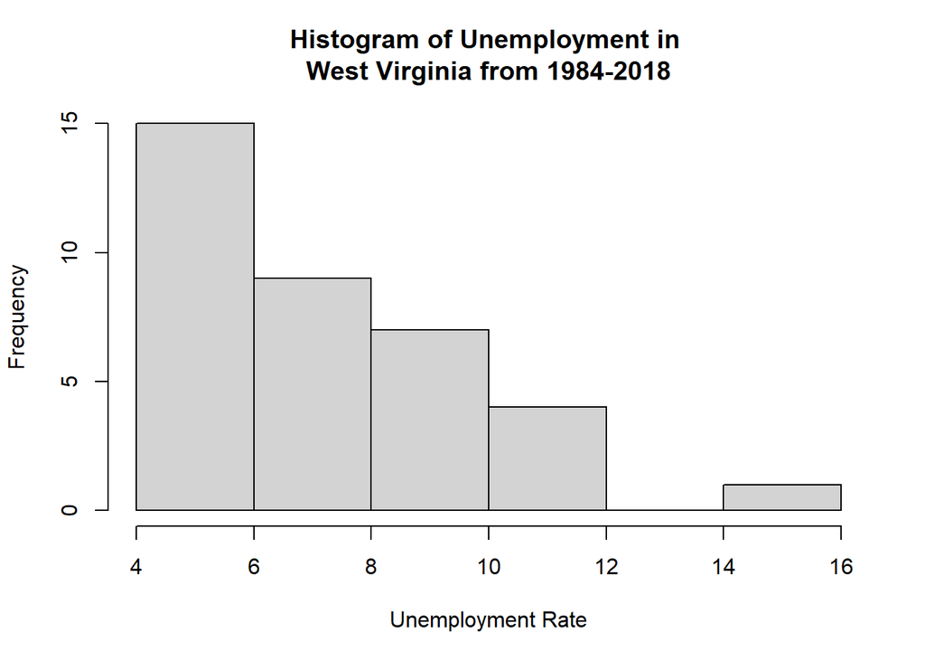

```r
hist(WV_data$unemployment,
     main="Histogram of Unemployment in \nWest Virginia from 1984-2018",
     xlab="Unemployment Rate",
     breaks = 5)
```

In West Virginia,from 1984 to 2018, the unemployment rate ranges from 4.2-14.4%. The histogram displays a positively skewed distribution. 15 out of the 36 years were characterized by unemployment rates in the lowest interval, 4.0-5.9%.

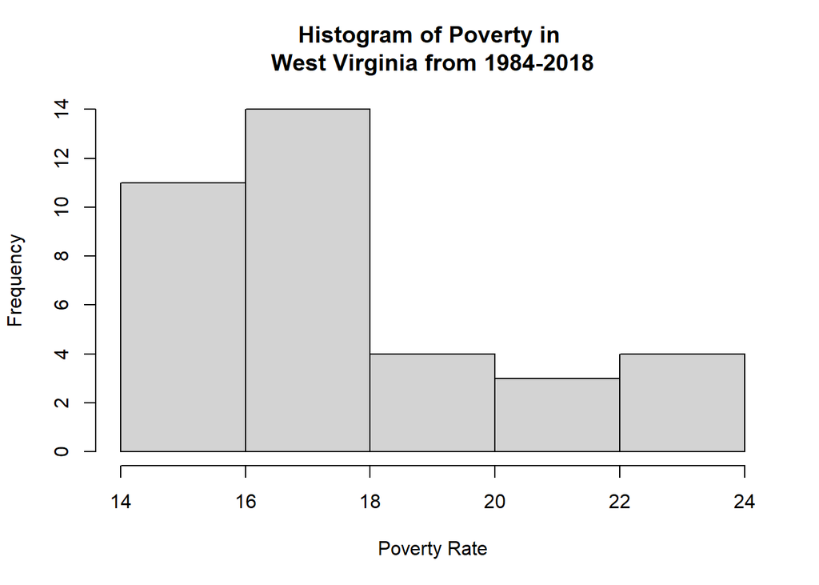

```r
hist(WV_data$poverty,
     main="Histogram of Poverty in \nWest Virginia from 1984-2018",
     xlab="Poverty Rate",
     breaks = 5)
```

## Scatter Plots: West Virginia

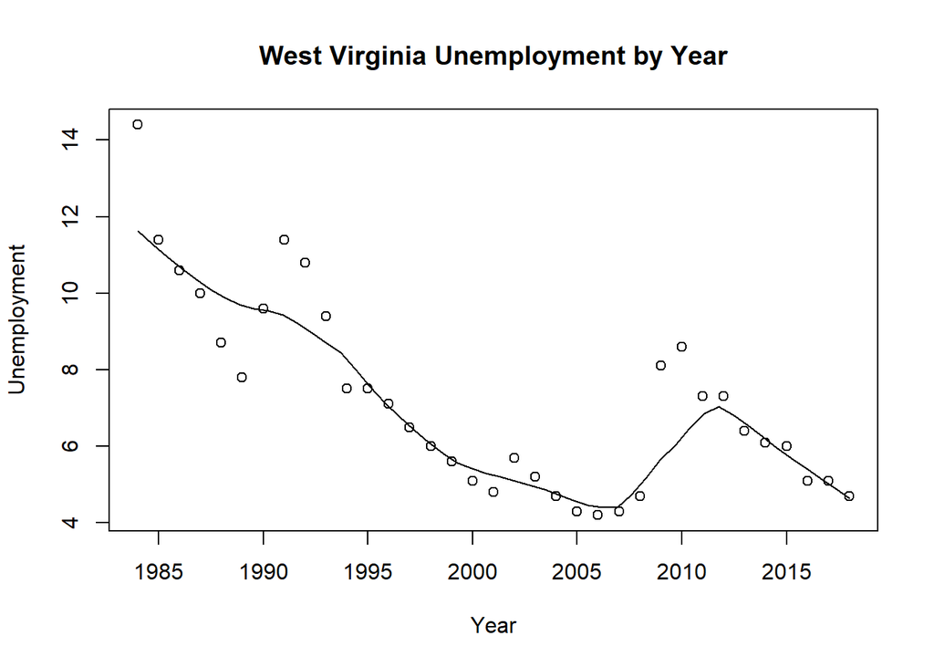

```r
scatter.smooth(WV_data$year, WV_data$unemployment, main="West Virginia Unemployment by Year", xlab = "Year", ylab = "Unemployment", span = 2/8)
```

Unemployment in the state of West Virginia from 1984-2007 shows a gradual decline with a cyclical pattern that is representative of most financial measures. One possible explanation for this phenomenon is that the job market is healthy and the state is in good standing. Leading up to the Great Recession in 2008-2009, we notice that the unemployment rate begins to creep up. It shoots up drastically following the stock market crash. Since that time the unemployment declined to the low levels seen before the 2008 market crash.

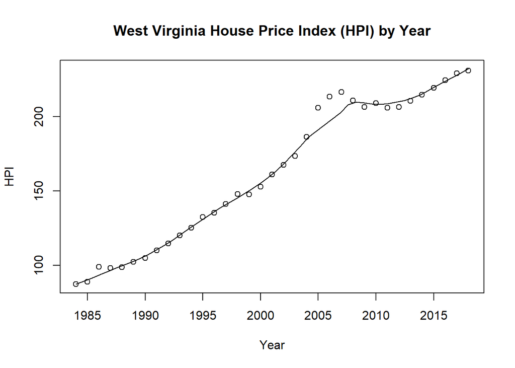

```r
scatter.smooth(WV_data$year, WV_data$HPI, main="West Virginia House Price Index (HPI) by Year", xlab = "Year", ylab = "HPI", span = 2/8)
```

The house price index in the state of West Virginia is much different than that of the poverty level and household income. The HPI steadily increases within the state starting in 1984. There is one small dip in the HPI that intersects with the time period of the Great Recession. As the scatter plot shows, the HPI dropped down for about two years and since then it has continued to increase at a steady pace. The scatter plot of housing price index approximates a positive linear relationship over the time period we examine.

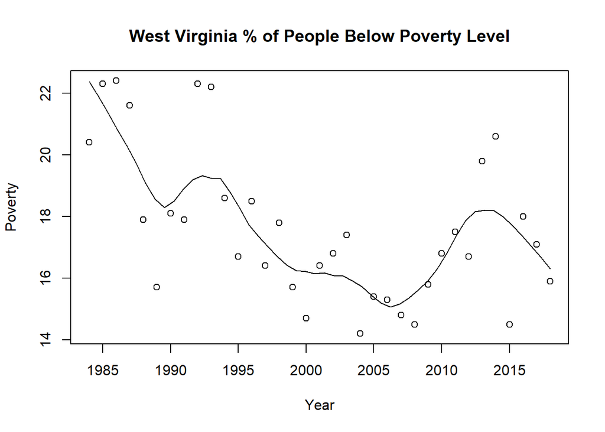

```r
scatter.smooth(x=WV_data$year, y=WV_data$poverty, main="West Virginia % of People Below Poverty Level", xlab = "Year", ylab = "Poverty",  span = 2/8)
```

The poverty rate in West Virginia is consistent with the other scatter plots. There is a definite cyclical trend to the data. As we can see in the scatter plot, the recession in the 1980s, the recession of the early 1990s, and the Great Recession all equate to a rise in the poverty level. The 2008 stock market crash affected the poverty level negatively for a few years until the stock market rebounded.

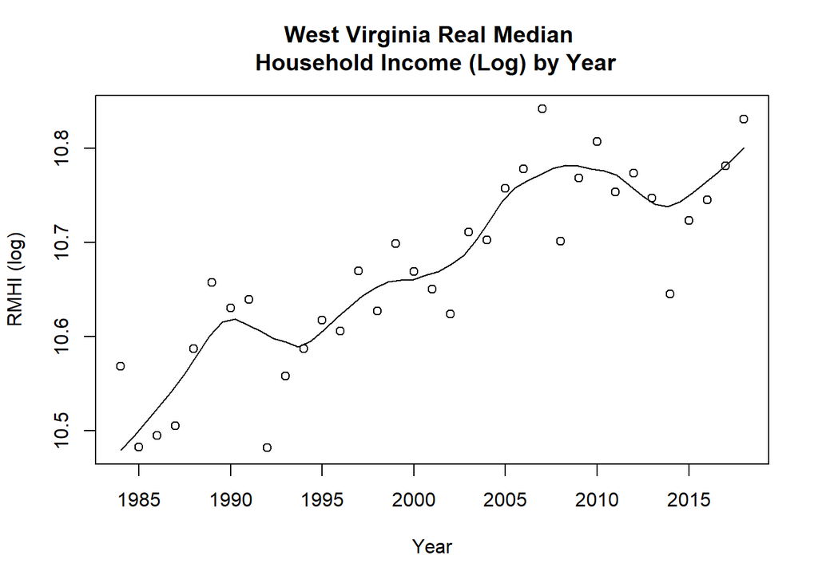

```r
#WV_data$log_RMHI <- as.integer(WV_data$log_RMHI)
scatter.smooth(x=WV_data$year, y=WV_data$log_RMHI, main="West Virginia Real Median \n Household Income (Log) by Year", xlab = "Year", ylab = "RMHI (log)", span = 2/8 )
```

As the scatter plot suggests for the state of West Virginia, the real median household income does fluctuate from year to year, but also shows a consistent increasing trend throughout the years. The dips on the median household income seem to come at times of economic recession. In the 1990s, the recession caused a drop in the median household income. Additionally, the stock market crash that occurred in 2008-2009 caused a drop in the median household income. Other than those two instances the median household income within the state has increased steadily.

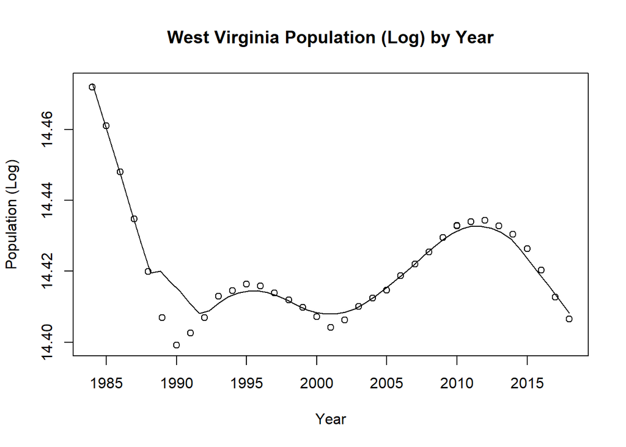

```r
#WV_data$log_pop <- as.integer(WV_data$log_pop)
scatter.smooth(x=WV_data$year, y=WV_data$log_pop, main="West Virginia Population (Log) by Year", xlab = "Year", ylab = "Population (Log)", span = 2/8)
```

The logarithmic value of the population’s scatter plot for the state of West Virginia shows a steep decline from 1984-1992. From 1990 to 1995 a slight increase in the population began, but after 1995 the population started to dwindle down again until 2001. From 2001, the population continues to increase steadily until 2012 and has been declining slightly ever since.

## Correlations: West Virginia

```r
cor(WV_data$HPI, WV_data$unemployment)
```

```
## [1] -0.7138695
```

The correlation between the house price index (HPI) and unemployment in West Virginia is -0.7138695. The correlation between HPI and unemployment is that of a strong negative correlation suggesting there is a significant inverse relationship between the two variables.

```r
cor(WV_data$poverty, WV_data$unemployment)
```

```
## [1] 0.6996082
```

The correlation between poverty, the proportion of the population below the poverty line, and unemployment in West Virginia is 0.6996082. The correlation between poverty and unemployment is that of a large positive correlation. A large positive correlation suggests that the two variables tend to move in the same direction unlike the housing price index. It also suggests that there is a significant relationship between the two variables.

```r
cor(WV_data$sp500, WV_data$unemployment)
```

```
## [1] 0.1979507
```

The correlation between the change in the S&P 500 index and unemployment in West Virginia is 0.1979507. The correlation between the S&P 500 and unemployment is a small positive correlation. This shows that there is a small positive relationship between the two variables signifying that the two variables tend to move in the same direction, however there is little evidence that there is significant interplay between the two variables.

```r
cor(WV_data$log_pop, WV_data$unemployment)
```

```
## [1] 0.509377
```

The correlation between the log of the population and unemployment in West Virginia is 0.509377. A positive correlation of 0.509377 suggests that these two variables maintain somewhat of a positive linear relationship.

```r
cor(WV_data$log_RMHI, WV_data$unemployment)
```

```
## [1] -0.6322822
```

The correlation between the logarithm of the real median household income and unemployment in West Virginia is -0.6322822. This large negative correlation suggests that as the log of the median household income increases, the unemployment tends to decrease.

## Boxplots: West Virginia

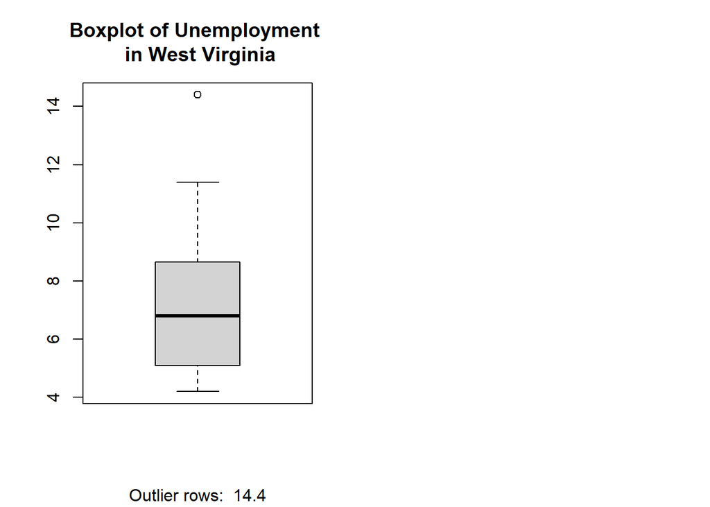

```r
par(mfrow=c(1, 2))
boxplot(WV_data$unemployment, main="Boxplot of Unemployment \n in West Virginia", sub=paste("Outlier rows: ", boxplot.stats(WV_data$unemployment)$out))
```

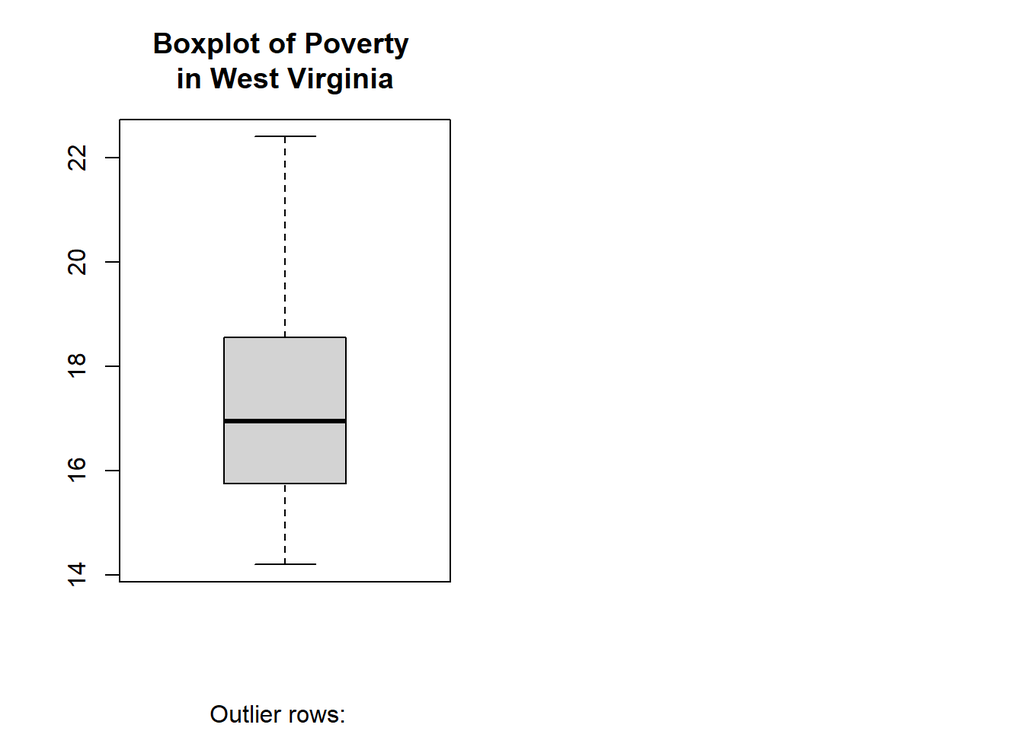

```r
par(mfrow=c(1, 2))
boxplot(WV_data$poverty, main="Boxplot of Poverty \nin West Virginia", sub=paste("Outlier rows: ", boxplot.stats(WV_data$poverty)$out))
```

The median of the poverty level within the state of West Virginia is around 17%. The first quartile begins at about 15.5% and the third quartile ends at 18.5%. There are not outliers in the poverty rate for the state of West Virginia over the time period the data was collected.

## Multiple Linear Regression: West Virginia

### Model 1: West Virginia

This project uses the ordinary least squares method to estimate the relationship between the independent variable and the dependent variable. The following model was estimated using OLS:

```r
WV_reg2 <- lm(unemployment ~ HPI + poverty + sp500 + log_pop + log_RMHI, data = WV_data)
summary(WV_reg2)
```

```
##
## Call:
## lm(formula = unemployment ~ HPI + poverty + sp500 + log_pop +
##     log_RMHI, data = WV_data)
##
## Residuals:
##     Min      1Q  Median      3Q     Max
## -1.6926 -0.7540 -0.3264  0.4607  3.0139
##
## Coefficients:
##               Estimate Std. Error t value Pr(>|t|)
## (Intercept) -9.132e+02  2.079e+02  -4.393 0.000129 ***
## HPI         -5.035e-02  9.467e-03  -5.319 9.47e-06 ***
## poverty      5.165e-01  1.477e-01   3.496 0.001492 **
## sp500       -1.345e-02  1.431e-02  -0.940 0.354765
## log_pop      5.187e+01  1.431e+01   3.624 0.001061 **
## log_RMHI     1.609e+01  5.719e+00   2.814 0.008561 **
## ---
## Signif. codes:  0 '***' 0.001 '**' 0.01 '*' 0.05 '.' 0.1 ' ' 1
##
## Residual standard error: 1.195 on 30 degrees of freedom
## Multiple R-squared:  0.801,  Adjusted R-squared:  0.7678
## F-statistic: 24.15 on 5 and 30 DF,  p-value: 1.1e-09
```

```r
anova(WV_reg2)
```

```
## Analysis of Variance Table
##
## Response: unemployment
##           Df  Sum Sq Mean Sq F value    Pr(>F)
## HPI        1 109.650 109.650 76.8172 8.982e-10 ***
## poverty    1  28.886  28.886 20.2367 9.559e-05 ***
## sp500      1   0.240   0.240  0.1680 0.6847914
## log_pop    1  22.265  22.265 15.5984 0.0004386 ***
## log_RMHI   1  11.301  11.301  7.9171 0.0085606 **
## Residuals 30  42.823   1.427
## ---
## Signif. codes:  0 '***' 0.001 '**' 0.01 '*' 0.05 '.' 0.1 ' ' 1
```

```r
ols_coll_diag(WV_reg2)
```

```
## Tolerance and Variance Inflation Factor
## ---------------------------------------
##   Variables Tolerance      VIF
## 1       HPI 0.1921071 5.205429
## 2   poverty 0.3178399 3.146238
## 3     sp500 0.7865598 1.271359
## 4   log_pop 0.7816725 1.279308
## 5  log_RMHI 0.1243312 8.043036
##
##
## Eigenvalue and Condition Index
## ------------------------------
##     Eigenvalue Condition Index    intercept          HPI      poverty
## 1 5.220466e+00        1.000000 3.330299e-08 0.0005128827 2.061019e-04
## 2 6.974607e-01        2.735866 1.576548e-08 0.0006961415 4.487238e-05
## 3 7.436053e-02        8.378830 2.529170e-07 0.1464818946 1.709796e-02
## 4 7.705448e-03       26.028892 1.330420e-05 0.1394099229 4.383202e-01
## 5 7.072680e-06      859.137415 2.105232e-02 0.6925417256 4.508103e-01
## 6 4.723534e-07     3324.459982 9.789341e-01 0.0203574327 9.352061e-02
##         sp500      log_pop     log_RMHI
## 1 0.007473935 3.378479e-08 3.864739e-07
## 2 0.765474858 1.595511e-08 1.853439e-07
## 3 0.045300219 2.586299e-07 1.793365e-06
## 4 0.003937528 1.307981e-05 1.692193e-04
## 5 0.175183627 2.285494e-02 9.979001e-01
## 6 0.002629833 9.771317e-01 1.928329e-03
```

According to the high VIF values (1.271-8.043), the independent variables show correlation with each other. Only one of the variables, Log_RMHI, has a VIF value close to the critical limit of 10. In this case the p-values are used to test significance of the independent variables on the dependent variable, unemployment. The p values indicate that four of the variables are statistically significant at the 5% level of significance. The fifth variable, sp500, is not significant in this model.

The overall fit of the estimated model appears to be substantial because the R-squared of the regression is quite high. The models coefficient of determination is 0.801 and the Adjusted R-squared value is 0.7678 which indicates that the model explains 76.78-80.10% of the variation in the unemployment rate data around its mean.

A second regression is made excluding the sp500 variable in an attempt to improve the model.

### Model 2: West Virginia

```r
WV_linearModelSignificant <- lm(unemployment ~ HPI + poverty + log_pop + log_RMHI, data = WV_data)
summary(WV_linearModelSignificant)
```

```
##
## Call:
## lm(formula = unemployment ~ HPI + poverty + log_pop + log_RMHI,
##     data = WV_data)
##
## Residuals:
##     Min      1Q  Median      3Q     Max
## -1.5470 -0.8177 -0.3669  0.4570  2.9174
##
## Coefficients:
##               Estimate Std. Error t value Pr(>|t|)
## (Intercept) -891.39494  206.20229  -4.323 0.000148 ***
## HPI           -0.04686    0.00869  -5.392 6.98e-06 ***
## poverty        0.46943    0.13872   3.384 0.001953 **
## log_pop       52.03697   14.28449   3.643 0.000975 ***
## log_RMHI      13.83239    5.17966   2.671 0.011952 *
## ---
## Signif. codes:  0 '***' 0.001 '**' 0.01 '*' 0.05 '.' 0.1 ' ' 1
##
## Residual standard error: 1.192 on 31 degrees of freedom
## Multiple R-squared:  0.7951, Adjusted R-squared:  0.7687
## F-statistic: 30.08 on 4 and 31 DF,  p-value: 2.838e-10
```

```r
anova(WV_linearModelSignificant)
```

```
## Analysis of Variance Table
##
## Response: unemployment
##           Df  Sum Sq Mean Sq F value    Pr(>F)
## HPI        1 109.650 109.650 77.1071 6.492e-10 ***
## poverty    1  28.886  28.886 20.3131 8.776e-05 ***
## log_pop    1  22.404  22.404 15.7543  0.000398 ***
## log_RMHI   1  10.142  10.142  7.1317  0.011952 *
## Residuals 31  44.084   1.422
## ---
## Signif. codes:  0 '***' 0.001 '**' 0.01 '*' 0.05 '.' 0.1 ' ' 1
```

```r
ols_coll_diag(WV_linearModelSignificant)
```

```
## Tolerance and Variance Inflation Factor
## ---------------------------------------
##   Variables Tolerance      VIF
## 1       HPI 0.2270992 4.403361
## 2   poverty 0.3592015 2.783953
## 3   log_pop 0.7817968 1.279105
## 4  log_RMHI 0.1509842 6.623208
##
##
## Eigenvalue and Condition Index
## ------------------------------
##     Eigenvalue Condition Index    intercept          HPI      poverty
## 1 4.914014e+00        1.000000 3.838575e-08 0.0006978933 0.0002637175
## 2 7.823541e-02        7.925314 2.103806e-07 0.1680930392 0.0181989463
## 3 7.741917e-03       25.193815 1.355911e-05 0.1686324232 0.4890071003
## 4 8.579904e-06      756.792735 1.793480e-02 0.6450709435 0.3735748718
## 5 4.735834e-07     3221.216815 9.820514e-01 0.0175057009 0.1189553641
##        log_pop     log_RMHI
## 1 3.846231e-08 5.342690e-07
## 2 2.128264e-07 1.752593e-06
## 3 1.316699e-05 2.051336e-04
## 4 1.846627e-02 9.992498e-01
## 5 9.815203e-01 5.427788e-04
```

The results of the second regression show that log_RHMI variable still has the incorrect sign. With the sp500 variable excluded, the VIF values decrease ranging between 1.279 and 6.623, but HPI and log_RMHI still show signs of multicollinearity. All p-values are still statistically significant at the 5% level of significance. The overall fit of the estimated model appears to be substantial because the R-sq of the regression is high. The models R-sq is 0.7951 which decreased compared to the first regression, but the adjusted R-squared, 0.7687, increased compared to the first regression. The adjusted coefficient of determination is a better indicator of fitness in the case of multiple regression and thus the model shows an improvement when excluding sp500.

## Summary: Multiple Linear Regression

Several conclusions were made using the multiple regression models for both West Virginia and Illinois. In all the models tested, the change in the S&P 500 index is never significant. This shows that the index offers little help in determining the unemployment rate. The models show that the unemployment rate might not be the sole factor in indicating the economies overall health. Poverty and population are significant in all of the models and both variables tend to have an effect on unemployment rate with the expected sign. There is a significant effect on the unemployment rate by real median household income in all the models. This is demonstrated by the fact that RMHI maintained reliable p-values, however the slope did not have the expected sign. The mode of RHMI show that an increase in real median household income would increase unemployment rate which will be contrary to our initial hypothesis. The relationship between house price index and unemployment is not consistent among all models.

## Time Series Analysis on Unemployment

The unemployment data we collected is considered a time series as it was measured on an annual basis. To further expand on the cyclical nature of our data we implemented a time series forecast using the Holt Method.

Time series data typically contains four components: trend, seasonal, cyclical, and random components. Trend is represented by the long-term movements in a data series, whether that be upward or downward. Seasonality is normally represented by repetitions that occur within a single year time period, whereas the cyclical component represents long-term trends that are usually a factor the economy. Typically, seasonal trends are easier to identify than cyclical trends because the time period of a seasonal trend is often known ahead of time. Random components represent the random and unexplained movements within the time series data.

As the unemployment data we collected is shown on an annual basis, we will be focusing on the trend, cyclical, random components in our analysis. The type of analysis we have chosen to focus on is called Holt Exponential Smoothing Method. This method is characterized by incorporating large upward and downward fluctuations in data series. Holt Exponential Smoothing is especially relevant because the dataset lacks seasonal variation.

### Time Series: Illinois

```r
IL_TS <- ts(IL_data$unemployment, start = c(1984), end = c(2018), frequency = 1)
#Stores start, end, and frequency of timeseries data

IL_TData <- window(IL_TS, end = c(2004))
IL_VData <- window(IL_TS, start = c(2005))
#Partitions the training and validation sets
```

In the above section of code, we begin our Holt analysis of Illinois by creating the time series with the TS function. We set the start and end values of our times series data equal to the time span our data stretches and set the frequency equal to one.

Using the window function we partition our data into a training set, IL_TData, and a validation set, IL_VData.

```r
IL_HUser <- ets(IL_TData, model = "AAN", alpha = 0.2, beta = 0.15)
summary(IL_HUser)
```

```
## ETS(A,Ad,N)
##
## Call:
##  ets(y = IL_TData, model = "AAN", alpha = 0.2, beta = 0.15)
##
##   Smoothing parameters:
##     alpha = 0.2
##     beta  = 0.15
##     phi   = 0.8
##
##   Initial states:
##     l = 9.1038
##     b = -0.492
##
##   sigma:  1.3058
##
##      AIC     AICc      BIC
## 77.43215 79.93215 81.61024
##
## Training set error measures:
##                      ME     RMSE       MAE       MPE     MAPE    MASE      ACF1
## Training set 0.01280128 1.139837 0.8591663 -1.525969 14.65093 1.26348 0.5841472
```

```r
#Training data set using user based parameters for alpha and beta for smoothing.
```

It is common for practitioners to provide user supplied values for alpha and beta (smoothing parameters) due to the fact that the computer generated values are known to over-fit models where the data perform well in the sample period, but does not exhibit the same performance in the future. In our data, we compare both user supplied and computer generated smoothing parameters. We then compare the error measures to determine which model is a better fit to our data. We used an alpha = 0.2 and beta = 0.15 when creating the user supplier parameters model.

The ets function above denotes the error, trend, and seasonality of the training set. The first letter in the model string represents that we want the error to be additive, the second letter represents that fact that we expect the trend type to be additive, and the third letter, “N”, represents the fact that we do not intend on incorporating seasonality into our model.

```r
IL_HCmp <- ets(IL_TData, model = "AAN")
summary(IL_HCmp)
```

```
## ETS(A,A,N)
##
## Call:
##  ets(y = IL_TData, model = "AAN")
##
##   Smoothing parameters:
##     alpha = 0.9999
##     beta  = 1e-04
##
##   Initial states:
##     l = 8.3553
##     b = -0.2338
##
##   sigma:  0.9784
##
##      AIC     AICc      BIC
## 68.58121 72.58121 73.80382
##
## Training set error measures:
##                     ME      RMSE       MAE      MPE     MAPE      MASE
## Training set 0.1120952 0.8803193 0.6387882 1.287488 10.53478 0.9393944
##                   ACF1
## Training set 0.0652965
```

```r
#Training data set using computer based parameters for alpha and beta for smoothing.
```

This is then replicated using the computer generated smoothing parameters and we obtain the output above. By comparing the root mean squared error(RMSE) and the mean absolute percentage error(MAPE) we can assess the fitness of the user supplier and computer generate models. The user supplied model has a higher RMSE and MAPE indicating that the computer generated model provides a better overall fit for making a forecast.

```r
IL_nV <- length(IL_VData)
IL_fUser <- forecast(IL_HUser, h = IL_nV)
IL_fCmp <- forecast(IL_HCmp, h = IL_nV)
```

The length function is used to set the number of observations equal to the length of the validation set. Then the forecast function is utilized to make a forecast based on the observations in our training set.

```r
accuracy(IL_fUser,IL_VData)
```

```
##                      ME     RMSE       MAE       MPE     MAPE     MASE
## Training set 0.01280128 1.139837 0.8591663 -1.525969 14.65093 1.263480
## Test set     0.22556242 2.075490 1.8905876 -5.598974 27.98416 2.780276
##                   ACF1 Theil's U
## Training set 0.5841472        NA
## Test set     0.6727078  1.402801
```

```r
accuracy(IL_fCmp,IL_VData)
```

```
##                     ME      RMSE       MAE       MPE     MAPE      MASE
## Training set 0.1120952 0.8803193 0.6387882  1.287488 10.53478 0.9393944
## Test set     3.0944149 3.8292855 3.3229011 37.967956 43.12811 4.8866193
##                   ACF1 Theil's U
## Training set 0.0652965        NA
## Test set     0.6934401  2.220317
```

The accuracy function is used to test the error term outputs that were created using the training set. When comparing the accuracy function results we see conflicting results in our validation set. The test set shows that the RMSE and MAPE of the user generated model provides a better fit for the performance of our data. Ultimately, we decided to continue the process using the computer generated model, but the user supplied model would work just as well.

#### Forecast: Illinois

```r
IL_HFinal <- ets(IL_TS, model = "AAN")
forecast(IL_HFinal, h=1)
```

```
##      Point Forecast    Lo 80    Hi 80    Lo 95    Hi 95
## 2019        4.41789 2.851058 5.984722 2.021628 6.814152
```

Finally, everything is brought together with the ets and forecast functions to forecast the unemployment level for the next period, 2019. The forecast generated shows that the expected value of the Illinois unemployment level in December 2019 is equal to 4.42% based on the trends that is observed in our model. Based on the forecast we expect that the unemployment will range from 2.85% to 5.98% at a 80% confidence interval. Additionally, we can be 95% confident that the unemployment value will fall between 2.02% and 6.81%. Based on the actual unemployment rate in IL for December 2019 of 3.5% our model was accurate at predicting the unemployment value at both the 95% and 80% confidence intervals.

### Time Series: West Virginia

```r
WV_TS <- ts(WV_data$unemployment, start = c(1984), end = c(2018), frequency = 1)
#Stores start, end, and frequency of timeseries data

WV_TData <- window(WV_TS, end = c(2004))
WV_VData <- window(WV_TS, start = c(2005))
#Partitions the training and validation sets
```

```r
WV_HUser <- ets(WV_TData, model = "AAN", alpha = 0.2, beta = 0.15)
summary(WV_HUser)
```

```
## ETS(A,Ad,N)
##
## Call:
##  ets(y = WV_TData, model = "AAN", alpha = 0.2, beta = 0.15)
##
##   Smoothing parameters:
##     alpha = 0.2
##     beta  = 0.15
##     phi   = 0.8
##
##   Initial states:
##     l = 12.7771
##     b = -1.5609
##
##   sigma:  1.6369
##
##      AIC     AICc      BIC
## 86.92211 89.42211 91.10020
##
## Training set error measures:
##                      ME     RMSE      MAE       MPE     MAPE     MASE     ACF1
## Training set -0.1320942 1.428802 1.148726 -3.883647 14.15979 1.228584 0.504785
```

```r
#Training data set using user based parameters for alpha and beta for smoothing.
```

```r
WV_HCmp <- ets(WV_TData, model = "AAN")
summary(WV_HCmp)
```

```
## ETS(A,Ad,N)
##
## Call:
##  ets(y = WV_TData, model = "AAN")
##
##   Smoothing parameters:
##     alpha = 0.9999
##     beta  = 2e-04
##     phi   = 0.8417
##
##   Initial states:
##     l = 15.9638
##     b = -1.8651
##
##   sigma:  1.1154
##
##      AIC     AICc      BIC
## 74.81012 80.81012 81.07726
##
## Training set error measures:
##                       ME      RMSE       MAE       MPE     MAPE      MASE
## Training set -0.07675973 0.9735733 0.6947987 -1.828428 8.590638 0.7431002
##                  ACF1
## Training set 0.271826
```

```r
#Training data set using computer based parameters for alpha and beta for smoothing.
```

With West Virginia, we setup the datasets and partitioned them into training and validation sets following similar steps to Illinois.

The user supplied model for the state of West Virginia has a higher RMSE and MAPE at 1.4288 and 14.1598, respectively. The computer generated model has a RMSE of 0.9736 and a MAPE of 8.5906 indicating that the computer generated model provides a better overall fit to our forecast.

```r
WV_nV <- length(WV_VData)
WV_fUser <- forecast(WV_HUser, h = WV_nV)
WV_fCmp <- forecast(WV_HCmp, h = WV_nV)
```

```r
accuracy(WV_fUser,WV_VData)
```

```
##                      ME     RMSE      MAE       MPE     MAPE     MASE      ACF1
## Training set -0.1320942 1.428802 1.148726 -3.883647 14.15979 1.228584 0.5047850
## Test set      1.7441115 2.355068 1.857933 23.491691 26.16469 1.987094 0.7058261
##              Theil's U
## Training set        NA
## Test set      1.672258
```

```r
accuracy(WV_fCmp,WV_VData)
```

```
##                       ME      RMSE       MAE       MPE      MAPE      MASE
## Training set -0.07675973 0.9735733 0.6947987 -1.828428  8.590638 0.7431002
## Test set      1.62448769 2.2608082 1.7776928 21.469084 25.065397 1.9012758
##                   ACF1 Theil's U
## Training set 0.2718260        NA
## Test set     0.7051023  1.604304
```

The accuracy function confirms that the computer generated model is a better overall fit to the data we are using to create the model. This is due to the fact that once again the validation set exhibits a lower RMSE and MAPE under the computer generated model.

#### Forecast: West Virginia

```r
WV_HFinal <- ets(WV_TS, model = "AAN")
forecast(WV_HFinal, h=1)
```

```
##      Point Forecast    Lo 80    Hi 80    Lo 95   Hi 95
## 2019       4.699914 3.200919 6.198909 2.407398 6.99243
```

The forecast for West Virginia shows us that the expected value of the unemployment level in December 2019 is equal to 4.70% based on the trends that were observed in the computer generated model. At an 80% confidence interval we expect West Virginia’s unemployment level to range from 3.20% to 6.20%. Additionally, we can be 95% confident that the unemployment rate will be in the 2.41% to 6.99% level. The actual unemployment rate for the State of West Virginia in December 2019 is 5%. Our model is accurate at both the 95% and 80% confidence intervals. 5% is also fairly close to the point estimate at 4.7% further signifying that our model produces accurate results.

# Conclusion